# Section 9: Tree-Based Methods

Pablo Arés Gastesi

2026-07-06

# 1 Introduction

So far every classifier we have studied — logistic regression, LDA, QDA — draws a **linear (or quadratic) boundary** through the predictor space. **Trees** take a completely different approach: instead of a global formula, they carve the predictor space into a set of simple, non-overlapping **rectangular regions**, and predict the same value (a class, or a number) for every observation that falls in a given region.

The idea is appealing for several reasons: trees make no distributional assumptions about the predictors, they handle qualitative predictors without creating dummy variables, and — crucially — they are easy to visualise and explain, since the resulting model is literally a flowchart of yes/no questions.

Trees can be used for **classification** (predicting a category, as with logistic regression and LDA) or **regression** (predicting a number, as with linear regression). We cover both in this note, using a clinical dataset (predicting anaemia from age and diabetes status) and the `iris` dataset for classification, and the `penguins` dataset for regression.

Further reading: [ISLR2 Chapter 8](https://www.statlearning.com/) covers tree-based methods in depth, including the ensemble methods (bagging, random forests, boosting) that build on top of individual trees.

# 2 Understanding trees: a toy example

## 2.1 Recursive binary splitting

A tree is built by **recursive binary splitting**: at each step, the algorithm looks at every predictor and every possible cutpoint, and chooses the single split that makes the two resulting groups as “pure” as possible (i.e. as dominated by one class as possible). It then repeats the process inside each of the two resulting groups, and so on, until some stopping rule is reached.

Let’s see this with a small toy dataset of 10 points in two classes, using two numeric predictors $X_1$ and $X_2$.

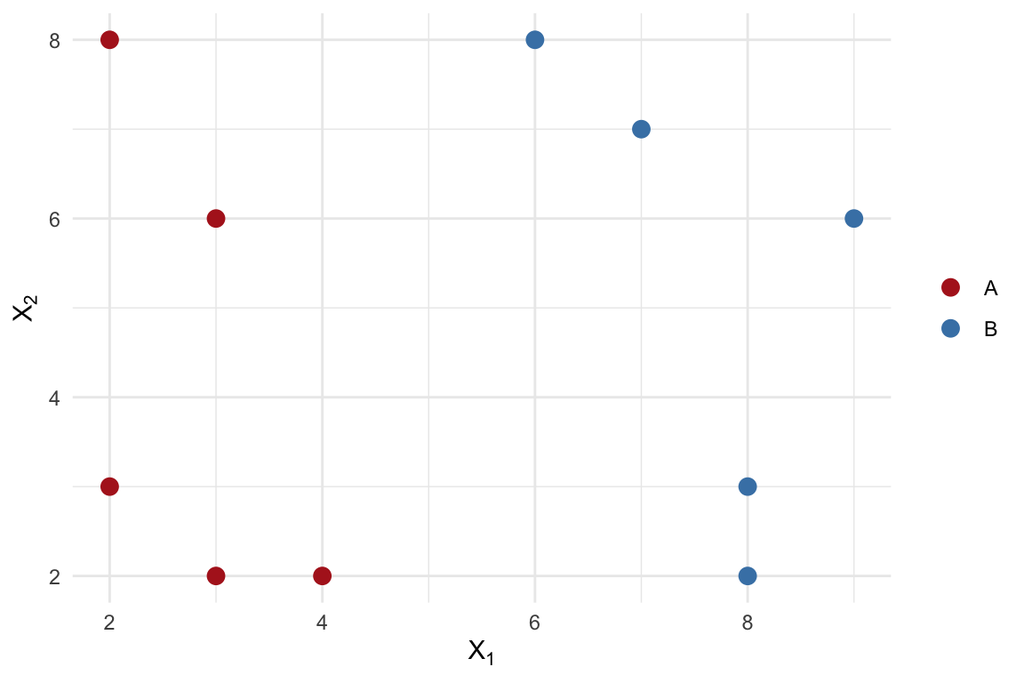

Figure 2.1: Toy example: two predictors, two classes

```r
toy <- data.frame(
  x1    = c(2, 3, 2, 4, 8, 7, 9, 3, 6, 8),
  x2    = c(3, 6, 8, 2, 3, 7, 6, 2, 8, 2),
  label = factor(c("A", "A", "A", "A", "B", "B", "B", "A", "B", "B"))
)

ggplot(toy, aes(x = x1, y = x2, colour = label)) +
  geom_point(size = 3) +
  scale_colour_manual(values = c(A = "firebrick", B = "steelblue")) +
  labs(x = expression(X[1]), y = expression(X[2]), colour = NULL) +
  theme_minimal()
```

A single split on $X_1$ already separates the two classes perfectly:

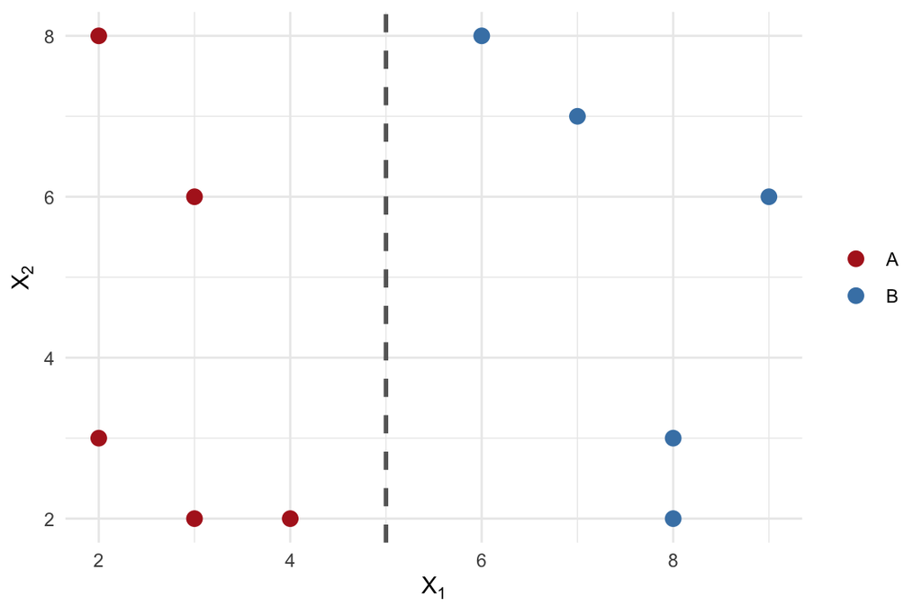

Figure 2.2: A single split at X1 = 5 perfectly separates the two classes

```r
ggplot(toy, aes(x = x1, y = x2, colour = label)) +
  geom_point(size = 3) +
  geom_vline(xintercept = 5, linetype = "dashed", colour = "grey40", linewidth = 1) +
  scale_colour_manual(values = c(A = "firebrick", B = "steelblue")) +
  labs(x = expression(X[1]), y = expression(X[2]), colour = NULL) +
  theme_minimal()
```

## 2.2 Measuring node purity: the Gini index

How does the algorithm know that $X_1 = 5$ is a good split? It needs a measure of **node impurity**. The most common one is the **Gini index**:

$$G = 1 - \sum_{k=1}^{K} \hat p_k^2$$

where $\hat p_k$ is the proportion of class $k$ observations in the node. $G = 0$ means the node is perfectly pure (a single class); $G$ is largest when classes are evenly mixed ($G = 0.5$ for two balanced classes).

A split is chosen to minimise the **weighted average Gini** of the two resulting child nodes. Let’s verify this by hand for our toy split:

```r
gini <- function(labels) {
  p <- table(labels) / length(labels)
  1 - sum(p^2)
}

gini_root  <- gini(toy$label)
left       <- toy$label[toy$x1 <= 5]
right      <- toy$label[toy$x1 >  5]
gini_left  <- gini(left)
gini_right <- gini(right)
gini_split <- (length(left) * gini_left + length(right) * gini_right) / nrow(toy)

cat("Gini before the split:      ", round(gini_root, 4), "\n")
```

```
## Gini before the split:       0.5
```

```r
cat("Gini in the left node (n =", length(left), "):", round(gini_left, 4), "\n")
```

```
## Gini in the left node (n = 5 ): 0
```

```r
cat("Gini in the right node (n =", length(right), "):", round(gini_right, 4), "\n")
```

```
## Gini in the right node (n = 5 ): 0
```

```r
cat("Weighted Gini after the split:", round(gini_split, 4), "\n")
```

```
## Weighted Gini after the split: 0
```

The split takes the Gini index from 0.5 down to 0 — a perfect (pure) split, since both children end up with a single class.

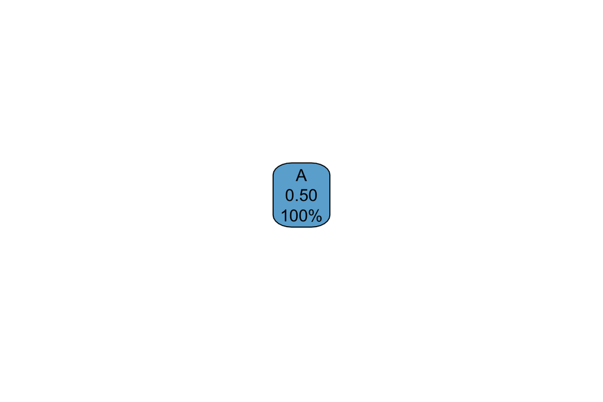

```r
tree_toy <- rpart(label ~ x1 + x2, data = toy, method = "class")
rpart.plot(tree_toy)
```

# 3 A first classification tree: clinical data

```r
clinicos <- read_csv("clinicos.csv", show_col_types = FALSE)
clinicos$anaemia <- factor(ifelse(clinicos$anaemia == 0, "No", "Yes"))
```

This dataset records clinical variables for 299 heart-failure patients. We start with a simple, deliberately modest example: can we predict whether a patient has **anaemia** from just their **age** and whether they have **diabetes**? We fit the tree with the `tree` package, the original implementation of CART in R.

## 3.1 Fitting with the `tree` package

```r
tree_anaemia <- tree(anaemia ~ age + diabetes, data = clinicos)
summary(tree_anaemia)
```

```
##
## Classification tree:
## tree(formula = anaemia ~ age + diabetes, data = clinicos)
## Variables actually used in tree construction:
## [1] "age"
## Number of terminal nodes:  5
## Residual mean deviance:  1.308 = 384.7 / 294
## Misclassification error rate: 0.398 = 119 / 299
```

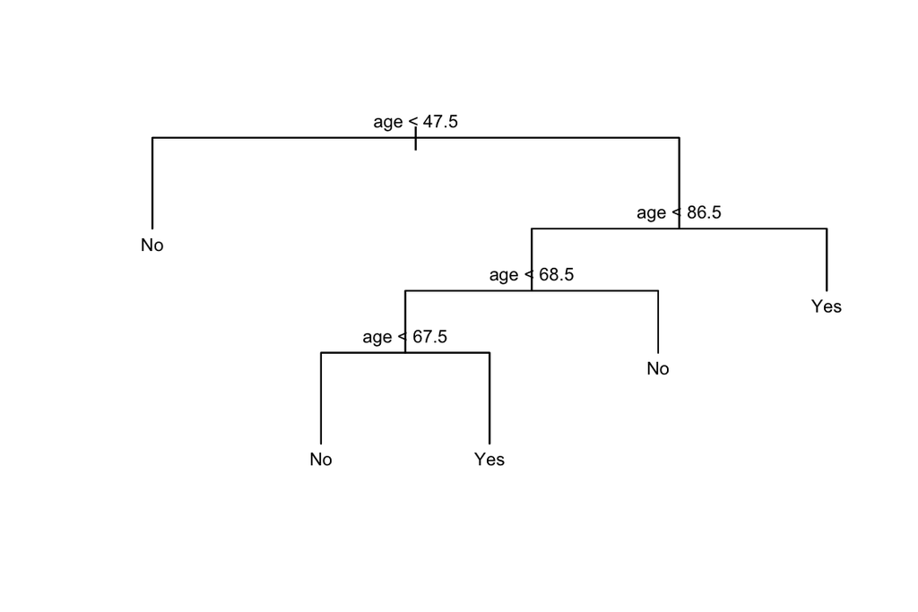

Figure 3.1: Classification tree for anaemia status (age + diabetes)

```r
plot(tree_anaemia)
text(tree_anaemia, pretty = 0, cex = 0.7)
```

## 3.2 Classification accuracy

```r
pred_tree <- predict(tree_anaemia, newdata = clinicos, type = "class")
cm_tree   <- table(Real = clinicos$anaemia, Predicted = pred_tree)
cm_tree
```

```
##      Predicted
## Real   No Yes
##   No  169   1
##   Yes 118  11
```

```r
cat("\nMisclassification rate:",
    round(mean(pred_tree != clinicos$anaemia) * 100, 2), "%\n")
```

```
##
## Misclassification rate: 39.8 %
```

That error rate is not much better than always predicting the majority class — `age` and `diabetes` alone are weak predictors of anaemia. Unlike the very clean iris and penguins examples elsewhere in this note, real clinical data is often like this: worth keeping in mind before assuming a tree (or any model) is doing something meaningful just because it produces a nice-looking diagram.

# 4 A second tree: the `rpart` package

The `tree` package is a little dated; in practice most people use `rpart` (Recursive Partitioning), paired with `rpart.plot` for much nicer diagrams. We illustrate it on the classic `iris` dataset.

## 4.1 The data

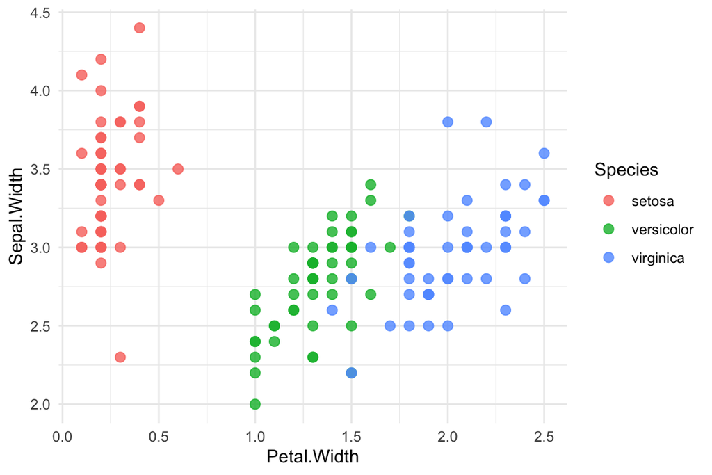

Figure 4.1: Iris: petal width vs sepal width by species

```r
ggplot(iris, aes(x = Petal.Width, y = Sepal.Width, colour = Species)) +
  geom_point(size = 2.5, alpha = 0.8) +
  theme_minimal()
```

## 4.2 Fitting and plotting the tree

```r
tree_iris <- rpart(Species ~ Petal.Width + Sepal.Width, data = iris)
```

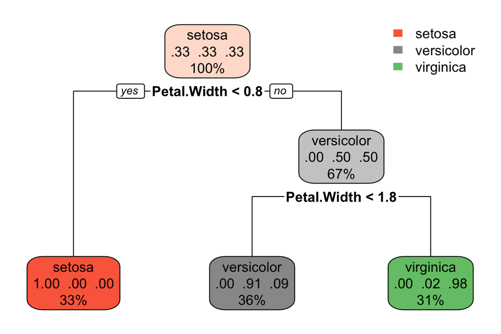

Figure 4.2: rpart tree for iris species using petal and sepal width

```r
rpart.plot(tree_iris)
```

## 4.3 Misclassification error

```r
pred_iris <- predict(tree_iris, newdata = iris, type = "class")
cat("Misclassification:", round(mean(pred_iris != iris$Species) * 100, 2), "%\n")
```

```
## Misclassification: 4 %
```

The tree fits the training data almost perfectly. As we know from the cross-validation note, this is exactly the setting where we should be suspicious of training error — a tree can easily be complex enough to memorise the training data without generalising well.

# 5 Overfitting: train vs. test error

## 5.1 Splitting the iris data

```r
set.seed(12345)
train_idx   <- sample(1:nrow(iris), round(nrow(iris) * 0.75), replace = FALSE)
tree_iris_tt <- rpart(Species ~ Petal.Width + Sepal.Width, data = iris[train_idx, ])
```

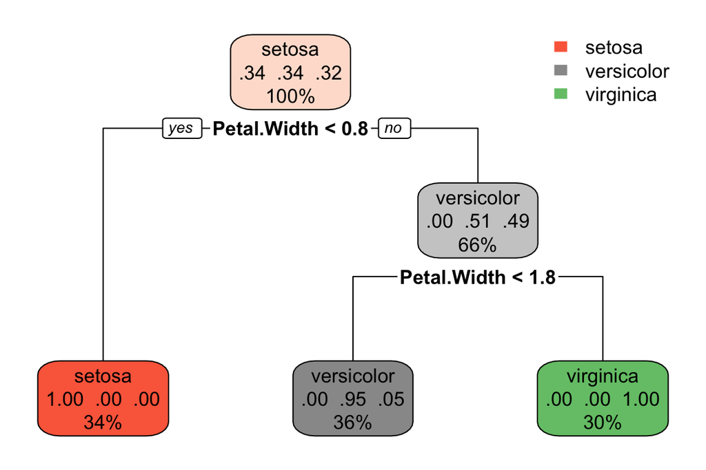

Figure 5.1: Tree fitted on 75% of the iris data (training set only)

```r
rpart.plot(tree_iris_tt)
```

## 5.2 Comparing training and test misclassification

```r
pred_train <- predict(tree_iris_tt, newdata = iris[train_idx, ],  type = "class")
pred_test  <- predict(tree_iris_tt, newdata = iris[-train_idx, ], type = "class")

miscl_train <- mean(pred_train != iris$Species[train_idx])
miscl_test  <- mean(pred_test  != iris$Species[-train_idx])

cat("Training misclassification:", round(miscl_train * 100, 2), "%\n")
```

```
## Training misclassification: 1.79 %
```

```r
cat("Test misclassification:    ", round(miscl_test * 100, 2), "%\n")
```

```
## Test misclassification:     10.53 %
```

```r
table(Predicted = pred_test, Real = iris$Species[-train_idx])
```

```
##             Real
## Predicted    setosa versicolor virginica
##   setosa         12          0         0
##   versicolor      0         11         3
##   virginica       0          1        11
```

As expected, the tree does somewhat worse on the held-out test data than on the data it was trained on — the same lesson as the cross-validation note, now illustrated with a tree instead of a polynomial regression.

# 6 Back to the clinical data set: controlling complexity

Left unconstrained, a tree can keep splitting until every leaf is pure (or has a single observation), which almost always overfits. `rpart` offers several knobs to control this via `rpart.control()`. We refit the same anaemia tree with `rpart` (rather than `tree`) since its control options are richer.

```r
tree_anaemia_rpart <- rpart(anaemia ~ age + diabetes, data = clinicos, method = "class")
```

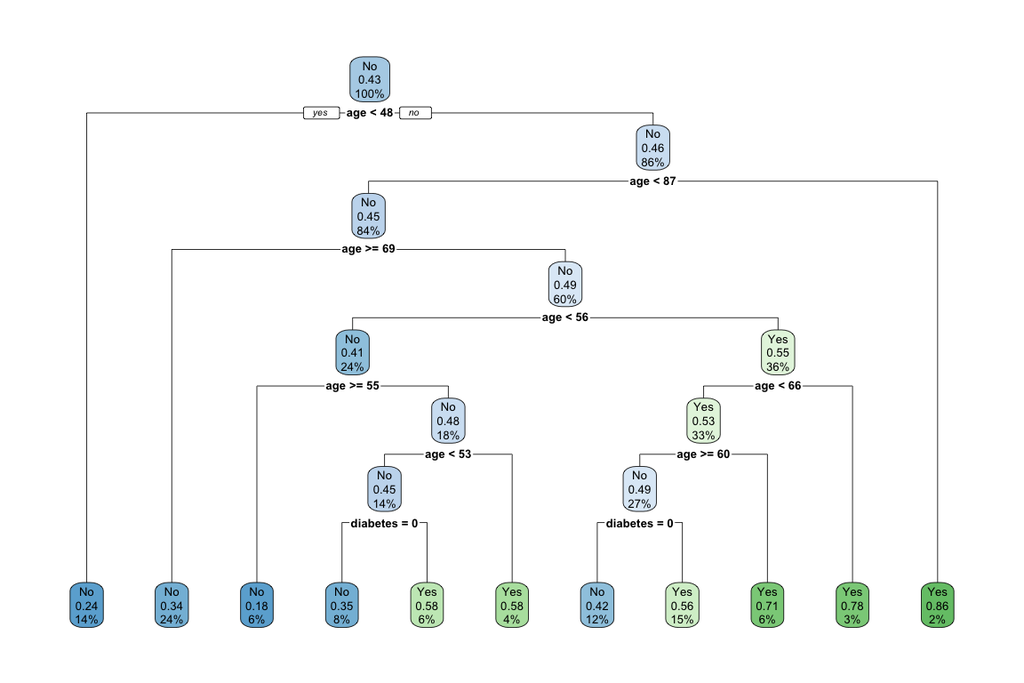

Figure 6.1: Default rpart tree for anaemia status

```r
rpart.plot(tree_anaemia_rpart)
```

## 6.1 The complexity parameter (`cp`)

`cp` sets the minimum improvement in fit required to keep a split — the higher `cp`, the smaller (more pruned) the tree.

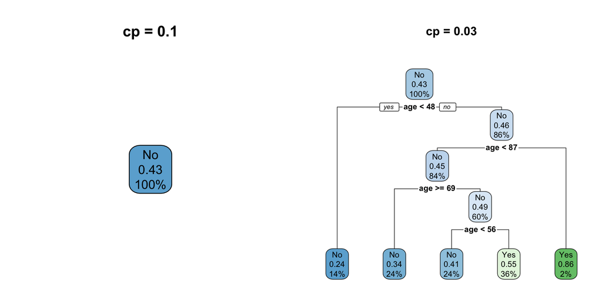

Figure 6.2: Effect of the complexity parameter cp on tree size

```r
tree_cp_high <- rpart(anaemia ~ age + diabetes, data = clinicos,
                      control = rpart.control(cp = 0.1), method = "class")
tree_cp_low  <- rpart(anaemia ~ age + diabetes, data = clinicos,
                      control = rpart.control(cp = 0.03), method = "class")

par(mfrow = c(1, 2))
rpart.plot(tree_cp_high, main = "cp = 0.1")
rpart.plot(tree_cp_low,  main = "cp = 0.03")
```

```r
par(mfrow = c(1, 1))
```

## 6.2 Limiting the depth (`maxdepth`)

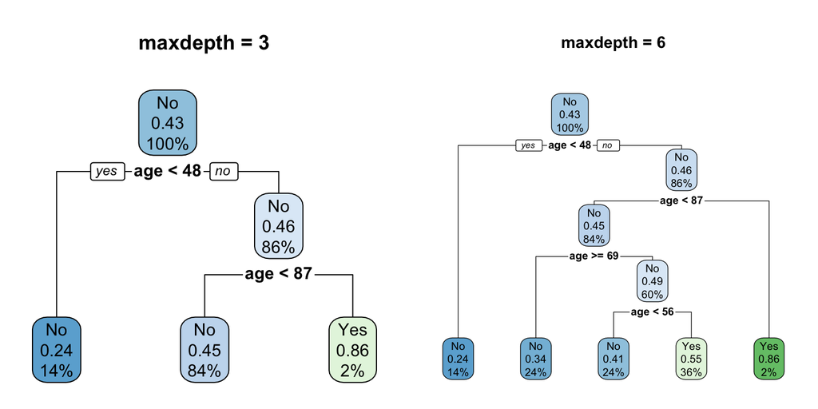

Figure 6.3: Effect of maxdepth on tree size

```r
tree_depth_3 <- rpart(anaemia ~ age + diabetes, data = clinicos,
                      control = rpart.control(maxdepth = 3), method = "class")
tree_depth_6 <- rpart(anaemia ~ age + diabetes, data = clinicos,
                      control = rpart.control(maxdepth = 6), method = "class")

par(mfrow = c(1, 2))
rpart.plot(tree_depth_3, main = "maxdepth = 3")
rpart.plot(tree_depth_6, main = "maxdepth = 6")
```

```r
par(mfrow = c(1, 1))
```

## 6.3 Comparing misclassification across settings

```r
compute_misclass <- function(fit) {
  pred <- predict(fit, newdata = clinicos, type = "class")
  round(mean(pred != clinicos$anaemia) * 100, 2)
}

misclass_df <- data.frame(
  Model = c("Default tree", "cp = 0.1", "cp = 0.03", "maxdepth = 3", "maxdepth = 6"),
  Misclassification_pct = c(
    compute_misclass(tree_anaemia_rpart),
    compute_misclass(tree_cp_high),
    compute_misclass(tree_cp_low),
    compute_misclass(tree_depth_3),
    compute_misclass(tree_depth_6)
  )
)
misclass_df
```

| Model | Misclassification_pct |
| --- | --- |
| Default tree | 34.11 |
| cp = 0.1 | 43.14 |
| cp = 0.03 | 37.79 |
| maxdepth = 3 | 41.47 |
| maxdepth = 6 | 37.79 |

More permissive settings (lower `cp`, higher `maxdepth`) let the tree grow larger and fit the *training* data better — but as with the iris example above, that is not the same as generalising better; it should always be checked against a test set or cross-validation, never training error alone.

# 7 Criteria for splitting: Gini vs. entropy

Besides the Gini index, the other common impurity measure is the **information / entropy** criterion:

$$D = -\sum_{k=1}^{K} \hat p_k \log_2 \hat p_k$$

Like Gini, entropy is 0 for a pure node and largest when classes are evenly mixed. In practice the two criteria usually produce very similar trees; occasionally they disagree on which variable to split first.

```r
tree_gini <- rpart(anaemia ~ age + diabetes, data = clinicos,
                   parms = list(split = "gini"),
                   control = rpart.control(cp = 0.03), method = "class")
tree_info <- rpart(anaemia ~ age + diabetes, data = clinicos,
                   parms = list(split = "information"),
                   control = rpart.control(cp = 0.03), method = "class")
```

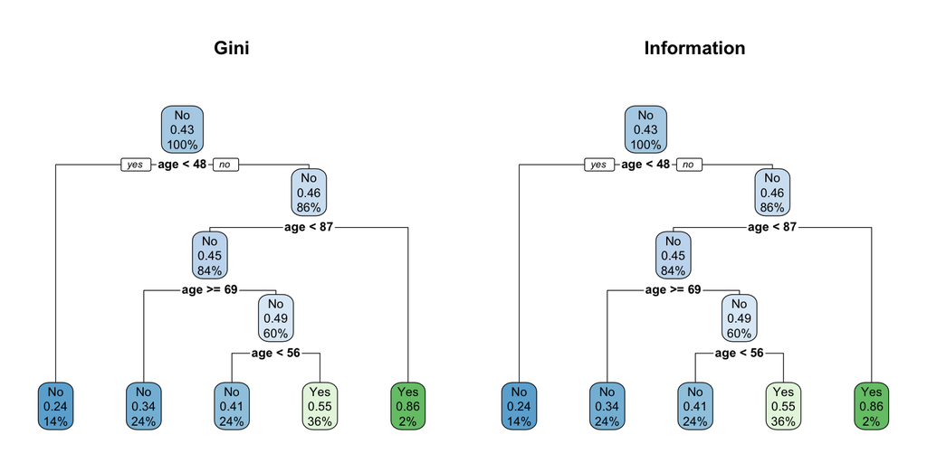

Figure 7.1: Trees fitted with Gini vs information (entropy) splitting criteria

```r
par(mfrow = c(1, 2))
rpart.plot(tree_gini, main = "Gini")
rpart.plot(tree_info, main = "Information")
```

```r
par(mfrow = c(1, 1))
```

```r
cat("Gini criterion misclassification:       ",
    compute_misclass(tree_gini), "%\n")
```

```
## Gini criterion misclassification:        37.79 %
```

```r
cat("Information criterion misclassification:",
    compute_misclass(tree_info), "%\n")
```

```
## Information criterion misclassification: 37.79 %
```

# 8 Regression trees

Everything so far has been a **classification** tree. When the response is numeric, we get a **regression tree** instead: each leaf predicts the *mean* of the training observations that fall into it, rather than a class.

We illustrate this with the `penguins` dataset (from `palmerpenguins`), predicting flipper length from the other measurements.

```r
tree_penguins <- rpart(flipper_length_mm ~ species + island + bill_length_mm +
                         bill_depth_mm + body_mass_g + sex, data = penguins)
```

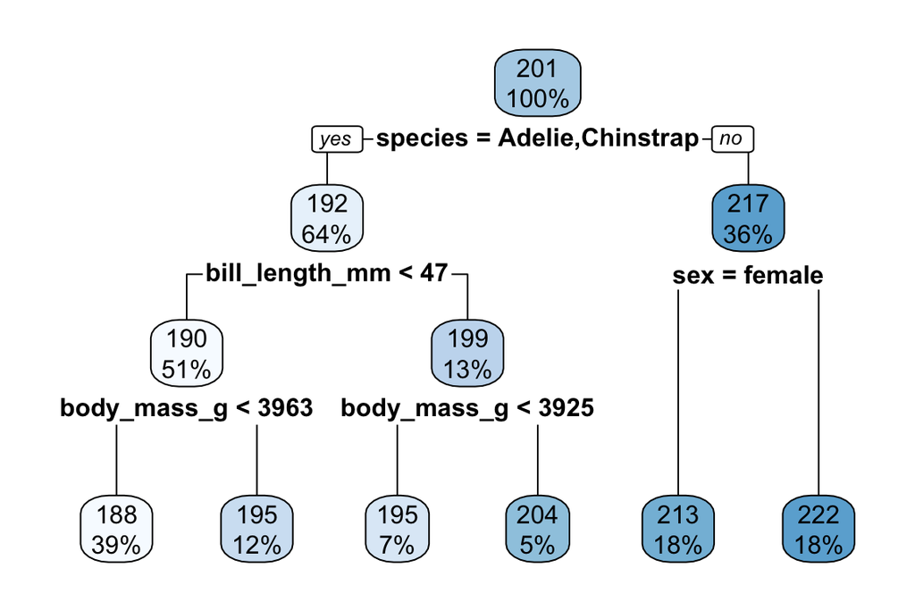

Figure 8.1: Regression tree predicting flipper length from other penguin measurements

```r
rpart.plot(tree_penguins)
```

## 8.1 Checking the result

Each leaf’s predicted value is simply the mean flipper length of the training observations that land there. We can check this directly for, say, male Gentoo penguins:

```r
gentoo_male <- subset(penguins, species == "Gentoo" & sex == "male")

cat("Share of Gentoo males in the data:",
    round(nrow(gentoo_male) * 100 / nrow(penguins), 2), "%\n")
```

```
## Share of Gentoo males in the data: 17.73 %
```

```r
cat("Mean flipper length for Gentoo males:",
    round(mean(gentoo_male$flipper_length_mm, na.rm = TRUE), 2), "mm\n")
```

```
## Mean flipper length for Gentoo males: 221.54 mm
```

```r
one_gentoo_male <- gentoo_male[1, c("species", "island", "bill_length_mm",
                                    "bill_depth_mm", "body_mass_g", "sex")]
predict(tree_penguins, newdata = one_gentoo_male)
```

```
##       1
## 221.541
```

The predicted value matches the group mean above, confirming that the tree’s prediction for any point is exactly the average response in its terminal node — nothing more.

## 8.2 Checking the accuracy of the model

For regression trees, the natural in-sample accuracy measure is the RMSE rather than a misclassification rate.

```r
pred_pen <- predict(tree_penguins, newdata = penguins)
actual   <- penguins$flipper_length_mm
ok       <- !is.na(actual)
rmse_pen <- sqrt(mean((pred_pen[ok] - actual[ok])^2))
cat("Training RMSE:", round(rmse_pen, 2), "mm\n")
```

```
## Training RMSE: 5.2 mm
```

As always, this is a *training* RMSE and will understate the true prediction error on new data; a proper evaluation would use a train/test split or cross-validation, exactly as in the classification examples above.

# 9 Advantages and disadvantages of trees

Trees have some clear strengths:

- They are easy to explain, even to a non-technical audience — the whole model is a flowchart.
- Some argue they mirror human decision-making more closely than regression approaches.
- No need to create dummy variables for qualitative predictors.
- They handle missing values and predictors on very different scales without extra preprocessing.
- They make no assumptions about the distribution of the predictors.

But they also have real weaknesses:

- Predictive accuracy is often lower than other methods (including the ones we’ve already covered — logistic regression, LDA/QDA).
- They are **not robust**: a small change in the training data can produce a very different tree.
- They are prone to **overfitting**, which is why individual trees are rarely used in practice; **ensembles of trees** — bagging, random forests, and boosting — combine many trees to fix exactly this weakness, at the cost of losing the simple, single-flowchart interpretability.

# 10 Summary

| Concept | Function | Notes |
| --- | --- | --- |
| Fit a classification/regression tree | `tree()` (`tree` package) or `rpart()` (`rpart` package) | `rpart` is the more modern, widely-used implementation |
| Plot a tree | `plot()` + `text()` (`tree`) or `rpart.plot()` (`rpart.plot`) | `rpart.plot` gives much nicer diagrams |
| Node impurity (classification) | Gini index or entropy/information | `parms = list(split = "gini")` / `"information"` |
| Control tree size | `rpart.control(cp = ..., maxdepth = ...)` | smaller `cp` / larger `maxdepth` → bigger tree |
| Classify new data | `predict(fit, newdata, type = "class")` |  |
| Regression tree prediction | `predict(fit, newdata)` | equals the mean response in the matching leaf |

Key takeaways: trees split the predictor space into rectangular regions via **recursive binary splitting**, choosing splits that minimise node impurity (Gini or entropy for classification, variance for regression). Left unconstrained they overfit badly, so their size must be controlled — via `cp`, `maxdepth`, or by pruning based on cross-validated error — and always evaluated on held-out data. Individual trees are simple and interpretable but not very accurate on their own; this motivates the ensemble methods (bagging, random forests, boosting) that typically follow this topic.